# Risk Factor Analysis

## Outcome Variable

**Outcome Variable:** stunted

## Predictor Variables

**Intervention Variable:** mage

**Adjustment Set:**

- arm
- meducyrs
- feducyrs
- W_mhtcm
- W_mwtkg
- W_mbmi
- single
- delta_meducyrs
- delta_feducyrs
- delta_W_mhtcm
- delta_W_mwtkg
- delta_W_mbmi
- delta_single

## Stratifying Variables

The analysis was stratified on these variable(s):

- agecat
- studyid
- country

## Data Summary

| agecat | studyid | country | mage | stunted | n_cell | n |
| --- | --- | --- | --- | --- | --- | --- |
| Birth | CMC-V-BCS-2002 | INDIA | [20-30) | 0 | 65 | 92 |
| Birth | CMC-V-BCS-2002 | INDIA | [20-30) | 1 | 14 | 92 |
| Birth | CMC-V-BCS-2002 | INDIA | <20 | 0 | 7 | 92 |
| Birth | CMC-V-BCS-2002 | INDIA | <20 | 1 | 2 | 92 |
| Birth | CMC-V-BCS-2002 | INDIA | >=30 | 0 | 3 | 92 |
| Birth | CMC-V-BCS-2002 | INDIA | >=30 | 1 | 1 | 92 |
| Birth | COHORTS | GUATEMALA | [20-30) | 0 | 386 | 852 |
| Birth | COHORTS | GUATEMALA | [20-30) | 1 | 19 | 852 |
| Birth | COHORTS | GUATEMALA | <20 | 0 | 112 | 852 |
| Birth | COHORTS | GUATEMALA | <20 | 1 | 9 | 852 |
| Birth | COHORTS | GUATEMALA | >=30 | 0 | 304 | 852 |
| Birth | COHORTS | GUATEMALA | >=30 | 1 | 22 | 852 |
| Birth | COHORTS | INDIA | [20-30) | 0 | 2795 | 4715 |
| Birth | COHORTS | INDIA | [20-30) | 1 | 385 | 4715 |
| Birth | COHORTS | INDIA | <20 | 0 | 309 | 4715 |
| Birth | COHORTS | INDIA | <20 | 1 | 59 | 4715 |
| Birth | COHORTS | INDIA | >=30 | 0 | 1053 | 4715 |
| Birth | COHORTS | INDIA | >=30 | 1 | 114 | 4715 |
| Birth | COHORTS | PHILIPPINES | [20-30) | 0 | 1725 | 3050 |
| Birth | COHORTS | PHILIPPINES | [20-30) | 1 | 96 | 3050 |
| Birth | COHORTS | PHILIPPINES | <20 | 0 | 342 | 3050 |
| Birth | COHORTS | PHILIPPINES | <20 | 1 | 36 | 3050 |
| Birth | COHORTS | PHILIPPINES | >=30 | 0 | 796 | 3050 |
| Birth | COHORTS | PHILIPPINES | >=30 | 1 | 55 | 3050 |
| Birth | EE | PAKISTAN | [20-30) | 0 | 61 | 239 |
| Birth | EE | PAKISTAN | [20-30) | 1 | 33 | 239 |
| Birth | EE | PAKISTAN | <20 | 0 | 0 | 239 |
| Birth | EE | PAKISTAN | <20 | 1 | 1 | 239 |
| Birth | EE | PAKISTAN | >=30 | 0 | 79 | 239 |
| Birth | EE | PAKISTAN | >=30 | 1 | 65 | 239 |

[output cut: 396 more lines]

The following strata were considered:

- agecat: 24 months, studyid: CMC-V-BCS-2002, country: INDIA
- agecat: 24 months, studyid: COHORTS, country: GUATEMALA
- agecat: 24 months, studyid: COHORTS, country: INDIA
- agecat: 24 months, studyid: COHORTS, country: PHILIPPINES
- agecat: 24 months, studyid: EE, country: PAKISTAN
- agecat: 24 months, studyid: GMS-Nepal, country: NEPAL
- agecat: 24 months, studyid: IRC, country: INDIA
- agecat: 24 months, studyid: JiVitA-3, country: BANGLADESH
- agecat: 24 months, studyid: Keneba, country: GAMBIA
- agecat: 24 months, studyid: LCNI-5, country: MALAWI
- agecat: 24 months, studyid: MAL-ED, country: BANGLADESH
- agecat: 24 months, studyid: MAL-ED, country: BRAZIL
- agecat: 24 months, studyid: MAL-ED, country: INDIA
- agecat: 24 months, studyid: MAL-ED, country: NEPAL
- agecat: 24 months, studyid: MAL-ED, country: PERU
- agecat: 24 months, studyid: MAL-ED, country: SOUTH AFRICA
- agecat: 24 months, studyid: MAL-ED, country: TANZANIA, UNITED REPUBLIC OF
- agecat: 24 months, studyid: NIH-Birth, country: BANGLADESH
- agecat: 24 months, studyid: NIH-Crypto, country: BANGLADESH
- agecat: 24 months, studyid: PROBIT, country: BELARUS
- agecat: 24 months, studyid: PROVIDE, country: BANGLADESH
- agecat: 24 months, studyid: TanzaniaChild2, country: TANZANIA, UNITED REPUBLIC OF
- agecat: 24 months, studyid: ZVITAMBO, country: ZIMBABWE
- agecat: 6 months, studyid: CMC-V-BCS-2002, country: INDIA
- agecat: 6 months, studyid: COHORTS, country: GUATEMALA
- agecat: 6 months, studyid: COHORTS, country: INDIA
- agecat: 6 months, studyid: COHORTS, country: PHILIPPINES
- agecat: 6 months, studyid: EE, country: PAKISTAN
- agecat: 6 months, studyid: GMS-Nepal, country: NEPAL
- agecat: 6 months, studyid: Guatemala BSC, country: GUATEMALA
- agecat: 6 months, studyid: IRC, country: INDIA
- agecat: 6 months, studyid: JiVitA-3, country: BANGLADESH
- agecat: 6 months, studyid: Keneba, country: GAMBIA
- agecat: 6 months, studyid: LCNI-5, country: MALAWI
- agecat: 6 months, studyid: MAL-ED, country: BANGLADESH
- agecat: 6 months, studyid: MAL-ED, country: BRAZIL
- agecat: 6 months, studyid: MAL-ED, country: INDIA
- agecat: 6 months, studyid: MAL-ED, country: NEPAL
- agecat: 6 months, studyid: MAL-ED, country: PERU
- agecat: 6 months, studyid: MAL-ED, country: SOUTH AFRICA
- agecat: 6 months, studyid: MAL-ED, country: TANZANIA, UNITED REPUBLIC OF
- agecat: 6 months, studyid: NIH-Birth, country: BANGLADESH
- agecat: 6 months, studyid: NIH-Crypto, country: BANGLADESH
- agecat: 6 months, studyid: PROBIT, country: BELARUS
- agecat: 6 months, studyid: PROVIDE, country: BANGLADESH
- agecat: 6 months, studyid: SAS-CompFeed, country: INDIA
- agecat: 6 months, studyid: SAS-FoodSuppl, country: INDIA
- agecat: 6 months, studyid: TanzaniaChild2, country: TANZANIA, UNITED REPUBLIC OF
- agecat: 6 months, studyid: ZVITAMBO, country: ZIMBABWE
- agecat: Birth, studyid: CMC-V-BCS-2002, country: INDIA
- agecat: Birth, studyid: COHORTS, country: GUATEMALA
- agecat: Birth, studyid: COHORTS, country: INDIA
- agecat: Birth, studyid: COHORTS, country: PHILIPPINES
- agecat: Birth, studyid: EE, country: PAKISTAN
- agecat: Birth, studyid: GMS-Nepal, country: NEPAL
- agecat: Birth, studyid: IRC, country: INDIA
- agecat: Birth, studyid: JiVitA-3, country: BANGLADESH
- agecat: Birth, studyid: Keneba, country: GAMBIA
- agecat: Birth, studyid: MAL-ED, country: BANGLADESH
- agecat: Birth, studyid: MAL-ED, country: BRAZIL
- agecat: Birth, studyid: MAL-ED, country: INDIA
- agecat: Birth, studyid: MAL-ED, country: NEPAL
- agecat: Birth, studyid: MAL-ED, country: PERU
- agecat: Birth, studyid: MAL-ED, country: SOUTH AFRICA
- agecat: Birth, studyid: MAL-ED, country: TANZANIA, UNITED REPUBLIC OF
- agecat: Birth, studyid: NIH-Birth, country: BANGLADESH
- agecat: Birth, studyid: NIH-Crypto, country: BANGLADESH
- agecat: Birth, studyid: PROBIT, country: BELARUS
- agecat: Birth, studyid: PROVIDE, country: BANGLADESH
- agecat: Birth, studyid: SAS-CompFeed, country: INDIA
- agecat: Birth, studyid: ZVITAMBO, country: ZIMBABWE

### Dropped Strata

Some strata were dropped due to rare outcomes:

- agecat: Birth, studyid: CMC-V-BCS-2002, country: INDIA
- agecat: Birth, studyid: EE, country: PAKISTAN
- agecat: Birth, studyid: IRC, country: INDIA
- agecat: Birth, studyid: MAL-ED, country: BRAZIL
- agecat: Birth, studyid: MAL-ED, country: INDIA
- agecat: Birth, studyid: MAL-ED, country: NEPAL
- agecat: Birth, studyid: MAL-ED, country: SOUTH AFRICA
- agecat: Birth, studyid: MAL-ED, country: TANZANIA, UNITED REPUBLIC OF
- agecat: 6 months, studyid: EE, country: PAKISTAN
- agecat: 6 months, studyid: MAL-ED, country: BRAZIL
- agecat: 6 months, studyid: MAL-ED, country: INDIA
- agecat: 6 months, studyid: MAL-ED, country: NEPAL
- agecat: 6 months, studyid: MAL-ED, country: TANZANIA, UNITED REPUBLIC OF
- agecat: 24 months, studyid: EE, country: PAKISTAN
- agecat: 24 months, studyid: MAL-ED, country: BRAZIL
- agecat: 24 months, studyid: MAL-ED, country: INDIA
- agecat: 24 months, studyid: MAL-ED, country: NEPAL
- agecat: 24 months, studyid: MAL-ED, country: TANZANIA, UNITED REPUBLIC OF
- agecat: 24 months, studyid: TanzaniaChild2, country: TANZANIA, UNITED REPUBLIC OF

## Methods Detail

We’re interested in the causal parameters $E[Y_a]$ for all values of $a \in \mathcal{A}$. These parameters represent the mean outcome if, possibly contrary to fact, we intervened to set all units to have $A=a$. Under the randomization and positivity assumptions, these are identified by the statistical parameters $\psi_a=E_W[E_{Y|A,W}(Y|A=a,W)]$. In addition, we’re interested in the mean of $Y$, $E[Y]$ under no intervention (the observed mean). We will estimate these parameters by using SuperLearner to fit the relevant likelihood factors – $E_{Y|A,W}(Y|A=a,W)$ and $p(A=a|W)$, and then updating our likelihood fit using a joint TMLE.

For unadjusted analyses ($W=\{\}$), initial likelihoods were estimated using Lrnr_glm to estimate the simple $E(Y|A)$ and Lrnr_mean to estimate $p(A)$. For adjusted analyses, a small library containing Lrnr_glmnet, Lrnr_xgboost, and Lrnr_mean was used.

Having estimated these parameters, we will then use the delta method to estimate relative risks and attributable risks relative to a prespecified baseline level of $A$.

# Results Detail

## Results Plots

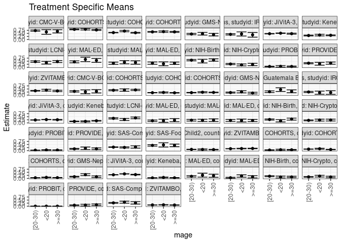

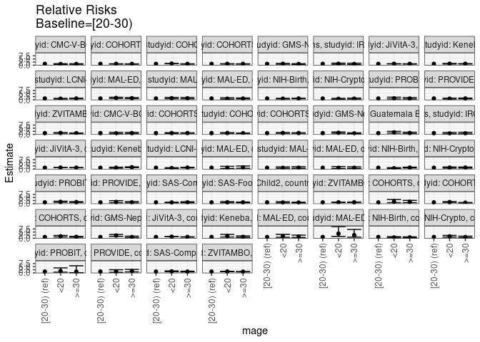

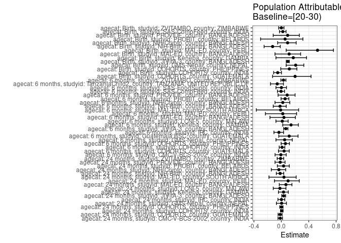

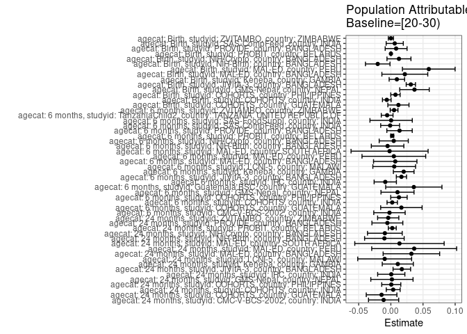

## Results Table

### Parameter: TSM

| agecat | studyid | country | intervention_level | baseline_level | estimate | ci_lower | ci_upper |
| --- | --- | --- | --- | --- | --- | --- | --- |
| Birth | COHORTS | GUATEMALA | [20-30) | NA | 0.0469136 | 0.0263077 | 0.0675195 |
| Birth | COHORTS | GUATEMALA | <20 | NA | 0.0743802 | 0.0276007 | 0.1211596 |
| Birth | COHORTS | GUATEMALA | >=30 | NA | 0.0674847 | 0.0402373 | 0.0947320 |
| Birth | COHORTS | INDIA | [20-30) | NA | 0.1246844 | 0.1129569 | 0.1364119 |
| Birth | COHORTS | INDIA | <20 | NA | 0.1554662 | 0.1181971 | 0.1927353 |
| Birth | COHORTS | INDIA | >=30 | NA | 0.0926985 | 0.0757845 | 0.1096125 |
| Birth | COHORTS | PHILIPPINES | [20-30) | NA | 0.0541473 | 0.0437304 | 0.0645642 |
| Birth | COHORTS | PHILIPPINES | <20 | NA | 0.0844672 | 0.0567137 | 0.1122208 |
| Birth | COHORTS | PHILIPPINES | >=30 | NA | 0.0603340 | 0.0447233 | 0.0759447 |
| Birth | GMS-Nepal | NEPAL | [20-30) | NA | 0.1385394 | 0.1060579 | 0.1710208 |
| Birth | GMS-Nepal | NEPAL | <20 | NA | 0.3062215 | 0.2285086 | 0.3839345 |
| Birth | GMS-Nepal | NEPAL | >=30 | NA | 0.1386541 | 0.0724090 | 0.2048992 |
| Birth | JiVitA-3 | BANGLADESH | [20-30) | NA | 0.2978736 | 0.2875060 | 0.3082413 |
| Birth | JiVitA-3 | BANGLADESH | <20 | NA | 0.3710936 | 0.3594994 | 0.3826878 |
| Birth | JiVitA-3 | BANGLADESH | >=30 | NA | 0.3115900 | 0.2860508 | 0.3371292 |
| Birth | Keneba | GAMBIA | [20-30) | NA | 0.0444286 | 0.0292876 | 0.0595695 |
| Birth | Keneba | GAMBIA | <20 | NA | 0.0779573 | 0.0415126 | 0.1144021 |
| Birth | Keneba | GAMBIA | >=30 | NA | 0.0504623 | 0.0319062 | 0.0690184 |
| Birth | MAL-ED | BANGLADESH | [20-30) | NA | 0.1687500 | 0.1105909 | 0.2269091 |
| Birth | MAL-ED | BANGLADESH | <20 | NA | 0.2666667 | 0.1080808 | 0.4252526 |
| Birth | MAL-ED | BANGLADESH | >=30 | NA | 0.2195122 | 0.0925394 | 0.3464850 |
| Birth | MAL-ED | PERU | [20-30) | NA | 0.0526316 | 0.0115533 | 0.0937099 |
| Birth | MAL-ED | PERU | <20 | NA | 0.1969697 | 0.1008138 | 0.2931256 |
| Birth | MAL-ED | PERU | >=30 | NA | 0.1320755 | 0.0407281 | 0.2234229 |
| Birth | NIH-Birth | BANGLADESH | [20-30) | NA | 0.1804878 | 0.1432301 | 0.2177455 |
| Birth | NIH-Birth | BANGLADESH | <20 | NA | 0.1142857 | 0.0396923 | 0.1888791 |
| Birth | NIH-Birth | BANGLADESH | >=30 | NA | 0.1190476 | 0.0624552 | 0.1756400 |
| Birth | NIH-Crypto | BANGLADESH | [20-30) | NA | 0.1253586 | 0.0956776 | 0.1550395 |
| Birth | NIH-Crypto | BANGLADESH | <20 | NA | 0.1858295 | 0.1176092 | 0.2540497 |
| Birth | NIH-Crypto | BANGLADESH | >=30 | NA | 0.1162302 | 0.0554873 | 0.1769732 |

[output cut: 126 more lines]

### Parameter: E(Y)

| agecat | studyid | country | intervention_level | baseline_level | estimate | ci_lower | ci_upper |
| --- | --- | --- | --- | --- | --- | --- | --- |
| Birth | COHORTS | GUATEMALA | NA | NA | 0.0586854 | 0.0428942 | 0.0744767 |
| Birth | COHORTS | INDIA | NA | NA | 0.1183457 | 0.1091247 | 0.1275667 |
| Birth | COHORTS | PHILIPPINES | NA | NA | 0.0613115 | 0.0527962 | 0.0698268 |
| Birth | GMS-Nepal | NEPAL | NA | NA | 0.1752874 | 0.1470202 | 0.2035545 |
| Birth | JiVitA-3 | BANGLADESH | NA | NA | 0.3289521 | 0.3215868 | 0.3363173 |
| Birth | Keneba | GAMBIA | NA | NA | 0.0537913 | 0.0425309 | 0.0650518 |
| Birth | MAL-ED | BANGLADESH | NA | NA | 0.1904762 | 0.1397281 | 0.2412242 |
| Birth | MAL-ED | PERU | NA | NA | 0.1115880 | 0.0710726 | 0.1521034 |
| Birth | NIH-Birth | BANGLADESH | NA | NA | 0.1600660 | 0.1308485 | 0.1892835 |
| Birth | NIH-Crypto | BANGLADESH | NA | NA | 0.1379781 | 0.1129774 | 0.1629789 |
| Birth | PROBIT | BELARUS | NA | NA | 0.0024473 | 0.0007336 | 0.0041610 |
| Birth | PROVIDE | BANGLADESH | NA | NA | 0.0890538 | 0.0649864 | 0.1131212 |
| Birth | SAS-CompFeed | INDIA | NA | NA | 0.2787540 | 0.2475949 | 0.3099131 |
| Birth | ZVITAMBO | ZIMBABWE | NA | NA | 0.1032165 | 0.0981467 | 0.1082863 |
| 6 months | CMC-V-BCS-2002 | INDIA | NA | NA | 0.3008130 | 0.2539566 | 0.3476694 |
| 6 months | COHORTS | GUATEMALA | NA | NA | 0.4099896 | 0.3788775 | 0.4411017 |
| 6 months | COHORTS | INDIA | NA | NA | 0.1959625 | 0.1848518 | 0.2070732 |
| 6 months | COHORTS | PHILIPPINES | NA | NA | 0.2112260 | 0.1958496 | 0.2266024 |
| 6 months | GMS-Nepal | NEPAL | NA | NA | 0.2163121 | 0.1823021 | 0.2503220 |
| 6 months | Guatemala BSC | GUATEMALA | NA | NA | 0.3115942 | 0.2568550 | 0.3663334 |
| 6 months | IRC | INDIA | NA | NA | 0.2457002 | 0.2038248 | 0.2875757 |
| 6 months | JiVitA-3 | BANGLADESH | NA | NA | 0.2514133 | 0.2432880 | 0.2595385 |
| 6 months | Keneba | GAMBIA | NA | NA | 0.1408654 | 0.1259115 | 0.1558193 |
| 6 months | LCNI-5 | MALAWI | NA | NA | 0.3736921 | 0.3370052 | 0.4103790 |
| 6 months | MAL-ED | BANGLADESH | NA | NA | 0.1825726 | 0.1336978 | 0.2314474 |
| 6 months | MAL-ED | PERU | NA | NA | 0.2197802 | 0.1705687 | 0.2689917 |
| 6 months | MAL-ED | SOUTH AFRICA | NA | NA | 0.1968504 | 0.1478551 | 0.2458457 |
| 6 months | NIH-Birth | BANGLADESH | NA | NA | 0.2672897 | 0.2297549 | 0.3048246 |
| 6 months | NIH-Crypto | BANGLADESH | NA | NA | 0.2097902 | 0.1799252 | 0.2396552 |
| 6 months | PROBIT | BELARUS | NA | NA | 0.0393401 | 0.0293640 | 0.0493162 |
| 6 months | PROVIDE | BANGLADESH | NA | NA | 0.1589404 | 0.1297581 | 0.1881227 |
| 6 months | SAS-CompFeed | INDIA | NA | NA | 0.2844311 | 0.2666491 | 0.3022132 |
| 6 months | SAS-FoodSuppl | INDIA | NA | NA | 0.4289474 | 0.3791199 | 0.4787748 |
| 6 months | TanzaniaChild2 | TANZANIA, UNITED REPUBLIC OF | NA | NA | 0.0964215 | 0.0835208 | 0.1093221 |
| 6 months | ZVITAMBO | ZIMBABWE | NA | NA | 0.1627181 | 0.1549406 | 0.1704957 |
| 24 months | CMC-V-BCS-2002 | INDIA | NA | NA | 0.7169811 | 0.6710815 | 0.7628807 |
| 24 months | COHORTS | GUATEMALA | NA | NA | 0.8120301 | 0.7885439 | 0.8355162 |
| 24 months | COHORTS | INDIA | NA | NA | 0.5674431 | 0.5514601 | 0.5834261 |
| 24 months | COHORTS | PHILIPPINES | NA | NA | 0.6229039 | 0.6036892 | 0.6421186 |
| 24 months | GMS-Nepal | NEPAL | NA | NA | 0.4487705 | 0.4045970 | 0.4929440 |
| 24 months | IRC | INDIA | NA | NA | 0.4205379 | 0.3726382 | 0.4684376 |
| 24 months | JiVitA-3 | BANGLADESH | NA | NA | 0.4912484 | 0.4781170 | 0.5043798 |
| 24 months | Keneba | GAMBIA | NA | NA | 0.3372229 | 0.3148351 | 0.3596107 |
| 24 months | LCNI-5 | MALAWI | NA | NA | 0.4526316 | 0.4078220 | 0.4974412 |
| 24 months | MAL-ED | BANGLADESH | NA | NA | 0.4764151 | 0.4090254 | 0.5438047 |
| 24 months | MAL-ED | PERU | NA | NA | 0.3681592 | 0.3013164 | 0.4350020 |
| 24 months | MAL-ED | SOUTH AFRICA | NA | NA | 0.3529412 | 0.2921001 | 0.4137823 |
| 24 months | NIH-Birth | BANGLADESH | NA | NA | 0.5690867 | 0.5220618 | 0.6161115 |
| 24 months | NIH-Crypto | BANGLADESH | NA | NA | 0.2568093 | 0.2190047 | 0.2946140 |
| 24 months | PROBIT | BELARUS | NA | NA | 0.0681537 | 0.0420376 | 0.0942697 |
| 24 months | PROVIDE | BANGLADESH | NA | NA | 0.3287197 | 0.2903909 | 0.3670485 |
| 24 months | ZVITAMBO | ZIMBABWE | NA | NA | 0.3473748 | 0.3243098 | 0.3704399 |

### Parameter: RR

| agecat | studyid | country | intervention_level | baseline_level | estimate | ci_lower | ci_upper |
| --- | --- | --- | --- | --- | --- | --- | --- |
| Birth | COHORTS | GUATEMALA | [20-30) | [20-30) | 1.0000000 | 1.0000000 | 1.0000000 |
| Birth | COHORTS | GUATEMALA | <20 | [20-30) | 1.5854719 | 0.7362135 | 3.4143916 |
| Birth | COHORTS | GUATEMALA | >=30 | [20-30) | 1.4384889 | 0.7921406 | 2.6122258 |
| Birth | COHORTS | INDIA | [20-30) | [20-30) | 1.0000000 | 1.0000000 | 1.0000000 |
| Birth | COHORTS | INDIA | <20 | [20-30) | 1.2468779 | 0.9639364 | 1.6128704 |
| Birth | COHORTS | INDIA | >=30 | [20-30) | 0.7434655 | 0.6056504 | 0.9126402 |
| Birth | COHORTS | PHILIPPINES | [20-30) | [20-30) | 1.0000000 | 1.0000000 | 1.0000000 |
| Birth | COHORTS | PHILIPPINES | <20 | [20-30) | 1.5599532 | 1.0667789 | 2.2811231 |
| Birth | COHORTS | PHILIPPINES | >=30 | [20-30) | 1.1142568 | 0.8079438 | 1.5367012 |
| Birth | GMS-Nepal | NEPAL | [20-30) | [20-30) | 1.0000000 | 1.0000000 | 1.0000000 |
| Birth | GMS-Nepal | NEPAL | <20 | [20-30) | 2.2103575 | 1.5646399 | 3.1225590 |
| Birth | GMS-Nepal | NEPAL | >=30 | [20-30) | 1.0008283 | 0.5879211 | 1.7037274 |
| Birth | JiVitA-3 | BANGLADESH | [20-30) | [20-30) | 1.0000000 | 1.0000000 | 1.0000000 |
| Birth | JiVitA-3 | BANGLADESH | <20 | [20-30) | 1.2458087 | 1.1917593 | 1.3023094 |
| Birth | JiVitA-3 | BANGLADESH | >=30 | [20-30) | 1.0460475 | 0.9573971 | 1.1429066 |
| Birth | Keneba | GAMBIA | [20-30) | [20-30) | 1.0000000 | 1.0000000 | 1.0000000 |
| Birth | Keneba | GAMBIA | <20 | [20-30) | 1.7546669 | 0.9839690 | 3.1290172 |
| Birth | Keneba | GAMBIA | >=30 | [20-30) | 1.1358075 | 0.6881325 | 1.8747241 |
| Birth | MAL-ED | BANGLADESH | [20-30) | [20-30) | 1.0000000 | 1.0000000 | 1.0000000 |
| Birth | MAL-ED | BANGLADESH | <20 | [20-30) | 1.5802469 | 0.7947195 | 3.1422159 |
| Birth | MAL-ED | BANGLADESH | >=30 | [20-30) | 1.3008130 | 0.6634287 | 2.5505598 |
| Birth | MAL-ED | PERU | [20-30) | [20-30) | 1.0000000 | 1.0000000 | 1.0000000 |
| Birth | MAL-ED | PERU | <20 | [20-30) | 3.7424242 | 1.4905555 | 9.3963221 |
| Birth | MAL-ED | PERU | >=30 | [20-30) | 2.5094340 | 0.8844567 | 7.1199176 |
| Birth | NIH-Birth | BANGLADESH | [20-30) | [20-30) | 1.0000000 | 1.0000000 | 1.0000000 |
| Birth | NIH-Birth | BANGLADESH | <20 | [20-30) | 0.6332046 | 0.3193333 | 1.2555786 |
| Birth | NIH-Birth | BANGLADESH | >=30 | [20-30) | 0.6595882 | 0.3928211 | 1.1075183 |
| Birth | NIH-Crypto | BANGLADESH | [20-30) | [20-30) | 1.0000000 | 1.0000000 | 1.0000000 |
| Birth | NIH-Crypto | BANGLADESH | <20 | [20-30) | 1.4823834 | 0.9575342 | 2.2949159 |
| Birth | NIH-Crypto | BANGLADESH | >=30 | [20-30) | 0.9271823 | 0.5221573 | 1.6463755 |

[output cut: 126 more lines]

### Parameter: PAR

| agecat | studyid | country | intervention_level | baseline_level | estimate | ci_lower | ci_upper |
| --- | --- | --- | --- | --- | --- | --- | --- |
| Birth | COHORTS | GUATEMALA | [20-30) | NA | 0.0117719 | -0.0046688 | 0.0282125 |
| Birth | COHORTS | INDIA | [20-30) | NA | -0.0063387 | -0.0130626 | 0.0003853 |
| Birth | COHORTS | PHILIPPINES | [20-30) | NA | 0.0071642 | -0.0001061 | 0.0144345 |
| Birth | GMS-Nepal | NEPAL | [20-30) | NA | 0.0367480 | 0.0137925 | 0.0597035 |
| Birth | JiVitA-3 | BANGLADESH | [20-30) | NA | 0.0310784 | 0.0238636 | 0.0382933 |
| Birth | Keneba | GAMBIA | [20-30) | NA | 0.0093627 | -0.0026471 | 0.0213726 |
| Birth | MAL-ED | BANGLADESH | [20-30) | NA | 0.0217262 | -0.0139411 | 0.0573935 |
| Birth | MAL-ED | PERU | [20-30) | NA | 0.0589564 | 0.0179966 | 0.0999162 |
| Birth | NIH-Birth | BANGLADESH | [20-30) | NA | -0.0204218 | -0.0394864 | -0.0013572 |
| Birth | NIH-Crypto | BANGLADESH | [20-30) | NA | 0.0126196 | -0.0060263 | 0.0312654 |
| Birth | PROBIT | BELARUS | [20-30) | NA | 0.0001341 | -0.0006282 | 0.0008964 |
| Birth | PROVIDE | BANGLADESH | [20-30) | NA | 0.0081913 | -0.0088047 | 0.0251872 |
| Birth | SAS-CompFeed | INDIA | [20-30) | NA | 0.0060306 | -0.0072839 | 0.0193450 |
| Birth | ZVITAMBO | ZIMBABWE | [20-30) | NA | 0.0000686 | -0.0039134 | 0.0040505 |
| 6 months | CMC-V-BCS-2002 | INDIA | [20-30) | NA | -0.0021438 | -0.0265464 | 0.0222589 |
| 6 months | COHORTS | GUATEMALA | [20-30) | NA | 0.0163762 | -0.0158319 | 0.0485842 |
| 6 months | COHORTS | INDIA | [20-30) | NA | 0.0021294 | -0.0059242 | 0.0101830 |
| 6 months | COHORTS | PHILIPPINES | [20-30) | NA | 0.0125971 | -0.0001776 | 0.0253719 |
| 6 months | GMS-Nepal | NEPAL | [20-30) | NA | 0.0103499 | -0.0153407 | 0.0360404 |
| 6 months | Guatemala BSC | GUATEMALA | [20-30) | NA | 0.0357151 | -0.0080227 | 0.0794528 |
| 6 months | IRC | INDIA | [20-30) | NA | -0.0086857 | -0.0260063 | 0.0086349 |
| 6 months | JiVitA-3 | BANGLADESH | [20-30) | NA | 0.0164551 | 0.0085315 | 0.0243787 |
| 6 months | Keneba | GAMBIA | [20-30) | NA | 0.0199815 | 0.0039091 | 0.0360539 |
| 6 months | LCNI-5 | MALAWI | [20-30) | NA | 0.0052394 | -0.0279856 | 0.0384644 |
| 6 months | MAL-ED | BANGLADESH | [20-30) | NA | 0.0068150 | -0.0269196 | 0.0405497 |
| 6 months | MAL-ED | PERU | [20-30) | NA | 0.0046635 | -0.0448596 | 0.0541866 |
| 6 months | MAL-ED | SOUTH AFRICA | [20-30) | NA | -0.0019913 | -0.0619049 | 0.0579224 |
| 6 months | NIH-Birth | BANGLADESH | [20-30) | NA | -0.0050903 | -0.0303836 | 0.0202030 |
| 6 months | NIH-Crypto | BANGLADESH | [20-30) | NA | 0.0044926 | -0.0181352 | 0.0271204 |
| 6 months | PROBIT | BELARUS | [20-30) | NA | 0.0021544 | -0.0001894 | 0.0044982 |
| 6 months | PROVIDE | BANGLADESH | [20-30) | NA | 0.0135074 | -0.0062395 | 0.0332543 |
| 6 months | SAS-CompFeed | INDIA | [20-30) | NA | -0.0011144 | -0.0157907 | 0.0135620 |
| 6 months | SAS-FoodSuppl | INDIA | [20-30) | NA | 0.0004175 | -0.0324911 | 0.0333261 |
| 6 months | TanzaniaChild2 | TANZANIA, UNITED REPUBLIC OF | [20-30) | NA | -0.0057667 | -0.0148972 | 0.0033638 |
| 6 months | ZVITAMBO | ZIMBABWE | [20-30) | NA | 0.0050104 | -0.0010314 | 0.0110522 |
| 24 months | CMC-V-BCS-2002 | INDIA | [20-30) | NA | -0.0112524 | -0.0347192 | 0.0122143 |
| 24 months | COHORTS | GUATEMALA | [20-30) | NA | -0.0144234 | -0.0382467 | 0.0093999 |
| 24 months | COHORTS | INDIA | [20-30) | NA | 0.0036643 | -0.0071355 | 0.0144640 |
| 24 months | COHORTS | PHILIPPINES | [20-30) | NA | 0.0006633 | -0.0141460 | 0.0154726 |
| 24 months | GMS-Nepal | NEPAL | [20-30) | NA | 0.0016769 | -0.0311777 | 0.0345316 |
| 24 months | IRC | INDIA | [20-30) | NA | 0.0006457 | -0.0205097 | 0.0218010 |
| 24 months | JiVitA-3 | BANGLADESH | [20-30) | NA | 0.0170598 | 0.0034083 | 0.0307112 |
| 24 months | Keneba | GAMBIA | [20-30) | NA | 0.0107955 | -0.0133730 | 0.0349641 |
| 24 months | LCNI-5 | MALAWI | [20-30) | NA | -0.0095906 | -0.0514911 | 0.0323100 |
| 24 months | MAL-ED | BANGLADESH | [20-30) | NA | 0.0319555 | -0.0119896 | 0.0759007 |
| 24 months | MAL-ED | PERU | [20-30) | NA | 0.0362772 | -0.0297436 | 0.1022980 |
| 24 months | MAL-ED | SOUTH AFRICA | [20-30) | NA | 0.0133961 | -0.0560948 | 0.0828870 |
| 24 months | NIH-Birth | BANGLADESH | [20-30) | NA | -0.0100452 | -0.0408182 | 0.0207279 |
| 24 months | NIH-Crypto | BANGLADESH | [20-30) | NA | -0.0093033 | -0.0362917 | 0.0176852 |
| 24 months | PROBIT | BELARUS | [20-30) | NA | 0.0022410 | -0.0039022 | 0.0083843 |
| 24 months | PROVIDE | BANGLADESH | [20-30) | NA | -0.0054097 | -0.0294381 | 0.0186186 |
| 24 months | ZVITAMBO | ZIMBABWE | [20-30) | NA | -0.0040901 | -0.0205746 | 0.0123943 |

### Parameter: PAF

| agecat | studyid | country | intervention_level | baseline_level | estimate | ci_lower | ci_upper |
| --- | --- | --- | --- | --- | --- | --- | --- |
| Birth | COHORTS | GUATEMALA | [20-30) | NA | 0.2005926 | -0.1282348 | 0.4335823 |
| Birth | COHORTS | INDIA | [20-30) | NA | -0.0535606 | -0.1118394 | 0.0016635 |
| Birth | COHORTS | PHILIPPINES | [20-30) | NA | 0.1168490 | -0.0087988 | 0.2268472 |
| Birth | GMS-Nepal | NEPAL | [20-30) | NA | 0.2096443 | 0.0704184 | 0.3280180 |
| Birth | JiVitA-3 | BANGLADESH | [20-30) | NA | 0.0944770 | 0.0721481 | 0.1162686 |
| Birth | Keneba | GAMBIA | [20-30) | NA | 0.1740569 | -0.0788044 | 0.3676499 |
| Birth | MAL-ED | BANGLADESH | [20-30) | NA | 0.1140625 | -0.0926693 | 0.2816809 |
| Birth | MAL-ED | PERU | [20-30) | NA | 0.5283401 | 0.0707564 | 0.7605977 |
| Birth | NIH-Birth | BANGLADESH | [20-30) | NA | -0.1275836 | -0.2517561 | -0.0157288 |
| Birth | NIH-Crypto | BANGLADESH | [20-30) | NA | 0.0914606 | -0.0535283 | 0.2164959 |
| Birth | PROBIT | BELARUS | [20-30) | NA | 0.0547917 | -0.3031102 | 0.3143951 |
| Birth | PROVIDE | BANGLADESH | [20-30) | NA | 0.0919811 | -0.1187609 | 0.2630255 |
| Birth | SAS-CompFeed | INDIA | [20-30) | NA | 0.0216340 | -0.0274596 | 0.0683817 |
| Birth | ZVITAMBO | ZIMBABWE | [20-30) | NA | 0.0006644 | -0.0386686 | 0.0385079 |
| 6 months | CMC-V-BCS-2002 | INDIA | [20-30) | NA | -0.0071266 | -0.0916071 | 0.0708159 |
| 6 months | COHORTS | GUATEMALA | [20-30) | NA | 0.0399429 | -0.0419500 | 0.1153993 |
| 6 months | COHORTS | INDIA | [20-30) | NA | 0.0108663 | -0.0310907 | 0.0511160 |
| 6 months | COHORTS | PHILIPPINES | [20-30) | NA | 0.0596382 | -0.0027995 | 0.1181884 |
| 6 months | GMS-Nepal | NEPAL | [20-30) | NA | 0.0478469 | -0.0785493 | 0.1594305 |
| 6 months | Guatemala BSC | GUATEMALA | [20-30) | NA | 0.1146205 | -0.0372583 | 0.2442607 |
| 6 months | IRC | INDIA | [20-30) | NA | -0.0353509 | -0.1082112 | 0.0327192 |
| 6 months | JiVitA-3 | BANGLADESH | [20-30) | NA | 0.0654505 | 0.0333658 | 0.0964702 |
| 6 months | Keneba | GAMBIA | [20-30) | NA | 0.1418482 | 0.0203169 | 0.2483033 |
| 6 months | LCNI-5 | MALAWI | [20-30) | NA | 0.0140206 | -0.0790208 | 0.0990392 |
| 6 months | MAL-ED | BANGLADESH | [20-30) | NA | 0.0373278 | -0.1661830 | 0.2053239 |
| 6 months | MAL-ED | PERU | [20-30) | NA | 0.0212189 | -0.2322227 | 0.2225331 |
| 6 months | MAL-ED | SOUTH AFRICA | [20-30) | NA | -0.0101156 | -0.3652456 | 0.2526375 |
| 6 months | NIH-Birth | BANGLADESH | [20-30) | NA | -0.0190440 | -0.1181675 | 0.0712923 |
| 6 months | NIH-Crypto | BANGLADESH | [20-30) | NA | 0.0214146 | -0.0925869 | 0.1235212 |
| 6 months | PROBIT | BELARUS | [20-30) | NA | 0.0547634 | -0.0041937 | 0.1102591 |
| 6 months | PROVIDE | BANGLADESH | [20-30) | NA | 0.0849838 | -0.0474863 | 0.2007011 |
| 6 months | SAS-CompFeed | INDIA | [20-30) | NA | -0.0039180 | -0.0568329 | 0.0463475 |
| 6 months | SAS-FoodSuppl | INDIA | [20-30) | NA | 0.0009733 | -0.0787677 | 0.0748201 |
| 6 months | TanzaniaChild2 | TANZANIA, UNITED REPUBLIC OF | [20-30) | NA | -0.0598072 | -0.1585109 | 0.0304870 |
| 6 months | ZVITAMBO | ZIMBABWE | [20-30) | NA | 0.0307919 | -0.0070500 | 0.0672118 |
| 24 months | CMC-V-BCS-2002 | INDIA | [20-30) | NA | -0.0156942 | -0.0490061 | 0.0165599 |
| 24 months | COHORTS | GUATEMALA | [20-30) | NA | -0.0177621 | -0.0475594 | 0.0111876 |
| 24 months | COHORTS | INDIA | [20-30) | NA | 0.0064575 | -0.0127593 | 0.0253097 |
| 24 months | COHORTS | PHILIPPINES | [20-30) | NA | 0.0010649 | -0.0229958 | 0.0245597 |
| 24 months | GMS-Nepal | NEPAL | [20-30) | NA | 0.0037367 | -0.0722338 | 0.0743245 |
| 24 months | IRC | INDIA | [20-30) | NA | 0.0015353 | -0.0500599 | 0.0505954 |
| 24 months | JiVitA-3 | BANGLADESH | [20-30) | NA | 0.0347274 | 0.0064896 | 0.0621626 |
| 24 months | Keneba | GAMBIA | [20-30) | NA | 0.0320131 | -0.0424188 | 0.1011303 |
| 24 months | LCNI-5 | MALAWI | [20-30) | NA | -0.0211884 | -0.1181045 | 0.0673270 |
| 24 months | MAL-ED | BANGLADESH | [20-30) | NA | 0.0670750 | -0.0300615 | 0.1550513 |
| 24 months | MAL-ED | PERU | [20-30) | NA | 0.0985367 | -0.1000584 | 0.2612792 |
| 24 months | MAL-ED | SOUTH AFRICA | [20-30) | NA | 0.0379556 | -0.1807181 | 0.2161301 |
| 24 months | NIH-Birth | BANGLADESH | [20-30) | NA | -0.0176514 | -0.0732054 | 0.0350269 |
| 24 months | NIH-Crypto | BANGLADESH | [20-30) | NA | -0.0362263 | -0.1467269 | 0.0636262 |
| 24 months | PROBIT | BELARUS | [20-30) | NA | 0.0328822 | -0.0580486 | 0.1159981 |
| 24 months | PROVIDE | BANGLADESH | [20-30) | NA | -0.0164569 | -0.0922782 | 0.0541012 |
| 24 months | ZVITAMBO | ZIMBABWE | [20-30) | NA | -0.0117744 | -0.0603591 | 0.0345841 |